# Investigating Plant-based vs. Meat-based Diets for Dogs

Author

Anna Ly

Published

October 1, 2024

## Dataset Sourcing & Application

We are using the “Vegan versus meat-based pet foods” dataset found on https://osf.io/nbepu/. A survey, approved by the UK General Data Protection Regulation, was deployed online and advertised through social media platforms and advertisements for dog owners from May 2020 to December 2020. More details can be found in [1].

The aim is to predict a dog’s diet type, meat-centric or plant-centric, based on health issues and demographic factors. Society believes it is animal abuse to feed a dog a plant-based diet since their ancestor, wolves, are carnivores; this analysis will help assess the association between a dog’s health and their diet.

In the survey, participants specified their dog’s diet, including raw, kibble, home-cooked, pescetarian, vegetarian, and vegan. Vegetarian and vegan diets were categorized as “plant-centric” and the others as “meat-centric.” Although the questionnaire allowed for other diet types, such as insects, only 26 responses included this, so they were excluded from the analysis.

## Data Transformation & Exploratory Data Analysis

After removing columns containing short answer responses, as well as users who answered “unsure” to at least one of the closed-form questions, **297 responses were removed** (the amount of rows of missing values), which led to a total of (n = 2342) participants. 183 of 297 were removed since most participants did not want to admit to their household income.

The analysis uses **13 variables** in total, with an extra 2 due to one-hot encoding (the owner’s gender and dog’s sex were each split into male/female indicators). Here is a brief summary of the **data types** for the selected variables:

- Numeric (transformed by the average of the range): owner’s age, dog’s age.
- Ordinal categorical (transformed into numeric): education level, household income, breed size, number of vet visits, dog’s health, owner’s meat consumption.
- Categorical (some transformed into binary): owner’s gender, dog’s sex, dog’s neuter status, whether the dog is on prescription medication, dog diet.

Furthermore, many questions asked for a range instead of a numerical value (such as age), so responses were transformed by taking the midpoint of the provided range. The exact details, including data cleaning, are shown in the supplementary material section.

Since most of the data came from closed-form questions which involved ranges, there were no extreme outliers. Surprisingly, there are outliers for highly educated dog owners who feed their dogs a meat-based diet (see Figure 2 in the supplementary material).

Due to space limitations, not all variables are discussed, but **summary tables** for income level and gender of the participants are provided:

Gender Distribution of Survey Participants

| Owner’s Gender | Count | Percentage (%) |
| --- | --- | --- |
| Female | 2189 | 92.44 |
| Male | 179 | 7.56 |

Self-reported Household Income Levels Compared to the Average Population

| Household Income Compared to Average | Count | Percentage (%) |
| --- | --- | --- |
| High | 358 | 15.12 |
| Low | 373 | 15.75 |
| Medium | 1637 | 69.13 |

More summary tables (3–9) are included in the supplementary material. Associations are also observed between a dog’s diet and both the owner’s diet and the dog’s overall health:

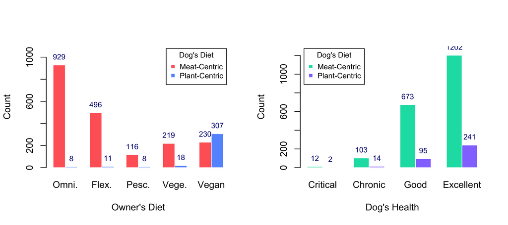

Barplots showing the distribution of dog diets by owner’s diet (left) and dog’s health (right).

The data were split into a training set (n = 781, 33.34%), a validation set (n = 781, 33.34%) and a hold-out set (n = 780, 33.33%) since the dataset is large and equal proportions allowed the models to be trained, validated, and tested fairly.

## K-Nearest Neighbour Analysis

**Model Evaluation:** the K-nn algorithm predicts the hold-out set with a 86.41% accuracy, so the misclassification rate is 13.59%.

## Logistic Regression Analysis (Without Shrinkage)

**Model Evaluation:** The misclassification rate for the logistic regression model without penalty for the hold-out set is 87.05%, which means the model is accurate 12.95% of the time.

**Compared to the K-nn algorithm**, the logistic regression model (without shrinkage) is significantly worse at predicting the dog’s diet.

## Logistic Regression (With Shrinkage)

1. The shrinkage value that performs best on this data set is $\lambda = 0.01253655$.
2. The model with shrinkage eliminates most of the covariates. The remaining covariates are: education level, owner’s age, owner’s diet, dog’s age, and number of vet visits.
3. The misclassification error rate for the logistic regression model with shrinkage for the hold-out set is 88.84%. This is worse than the model without shrinkage. This could be caused by the fact that logistic regression may be a poor way to model the data (i.e., there are model assumptions) or that transformations of the covariates are required to properly fit the dataset.

## Conclusions from Analysis

The K-nn algorithm outperforms logistic regression (both with and without shrinkage) in predicting a dog’s diet. Both logistic regression models show that owner’s diet is strongly associated with the dog’s diet. The relationship between the owner’s diet and the dog’s diet is intuitive; owners who eat less meat are likely to feed their pets less meat.

Fortunately, dogs with a plant-based diet do not seem to have more health complications compared to their meat-eating counterparts, but this could be due to participation bias: owners who feed their dogs a plant-based diet may insist their dogs are healthy to justify their peculiar diet.

## Is Generative AI Possible?

If you use Bing Copilot, you could try asking it to find a dataset; however, none of the ones it suggested were usable for this project. If provided a link to a dataset, Bing Copilot would create a description that sounds legitimate but it would not accurately capture how the dataset was properly sourced.

Furthermore, if asked to do some exploratory data analysis, it would suggest code that was not ready to use. However, with enough prompting and context from the user, it provided practical code for data cleaning, printing out summaries, potential graphs, model building, and some analysis.

Hence, it can do large portions of the assignment but would struggle in the beginning with picking a viable dataset and properly citing the source material. Prompts are shown in [2], [3], [4], and [5].

## References

[1]

Knight, A and Satchell, L (2021 ). Vegan versus meat-based pet foods: Owner-reported palatability behaviours and implications for canine and feline welfare. *PLoS One*. Public Library of Science San Francisco, CA USA. **16** e0253292

[2]

Bing Copilot (2024 ). Interaction with Bing Copilot on Finding a Dataset for Analysis. Prompt: "Can you find an interesting dataset for me to do analysis on Google Database Search related to vegans?", Copilot.Microsoft.com. https://copilot.microsoft.com/

[3]

Bing Copilot (2024 ). Interaction with Bing Copilot on Finding a Dataset for Analysis. Prompt: "Based off of the data found here: https://osf.io/nbepu/, briefly describe how the dataset was sourced and describe the chosen dataset (what are variables and observations).", Copilot.Microsoft.com. https://copilot.microsoft.com/

[4]

Bing Copilot (2024 ). Interaction with Bing Copilot on Finding a Dataset for Analysis. Prompt: "Clearly describe the application (classification) you are investigating based on the selected dataset.", Copilot.Microsoft.com. https://copilot.microsoft.com/

[5]

Bing Copilot (2024 ). Interaction with Bing Copilot on Finding a Dataset for Analysis. Prompt: "Given the following variables: c("education_lvl", "household_income", "owner_age", "owner_gender", "owner_diet", "breed_size", "dog_age", "sex_and_neuter_status", "vet_visit", "dog_meds", "dog_health", "dog_diet"), can you produce produce numerical and graphical summaries of the data in R? Furthermore, can you create a k-nn and logistic regression model?", Copilot.Microsoft.com. https://copilot.microsoft.com/

[6]

(2024 ). GitHub copilot · your AI pair programmer. GitHub. https://github.com/features/copilot/

[7]

Wickham, H, Averick, M, Bryan, J, Chang, W, McGowan, L D, François, R, Grolemund, G, Hayes, A, Henry, L, Hester, J, Kuhn, M, Pedersen, T L, Miller, E, Bache, S M, Müller, K, Ooms, J, Robinson, D, Seidel, D P, Spinu, V, Takahashi, K, Vaughan, D, Wilke, C, Woo, K and Yutani, H (2019 ). [Welcome to the tidyverse](https://doi.org/10.21105/joss.01686). *Journal of Open Source Software*. **4** 1686

[8]

Wickham, H and Bryan, J (2023 ). *Readxl: Read Excel Files*. https://CRAN.R-project.org/package=readxl

[9]

Venables, W N and Ripley, B D (2002 ). *Modern Applied Statistics with s*, Fourth. Springer, New York. https://www.stats.ox.ac.uk/pub/MASS4/

[10]

Sing, T, Sander, O, Beerenwinkel, N and Lengauer, T (2005 ). ROCR: Visualizing classifier performance in r. *Bioinformatics*. **21** 7881. http://rocr.bioinf.mpi-sb.mpg.de

[11]

Robin, X, Turck, N, Hainard, A, Tiberti, N, Lisacek, F, Sanchez, J-C and Müller, M (2011 ). pROC: An open-source package for r and s+ to analyze and compare ROC curves. *BMC Bioinformatics*. **12** 77

[12]

Tay, J K, Narasimhan, B and Hastie, T (2023 ). [Elastic net regularization paths for all generalized linear models](https://doi.org/10.18637/jss.v106.i01). *Journal of Statistical Software*. **106** 1–31

## Supplementary Material

Comments in the code below indicate where GitHub Copilot [6] was used.

### data_transformation_ref.R

This code was used as a reference for how the survey responses were transformed into binary or quantitative variables.

```r
# Github Copilot helped write some of these.
dog_diet_levels = c("Meat-based – conventional"   = "Meat", "Meat-based – raw" = "Meat",
  "Meat-based – lab-grown"  = "Meat", "Vegan (consuming no animal products)" = "Plant",  "Vegetarian (including eggs or milk, but not meat)" = "Plant", "Mixture" = "Other",
  "Fungi-based" = "Other", "Insect-based" = "Other", "Algae–based" = "Other", "Unsure" = "Other")

owner_diet_levels = c("Omnivore (i.e. eat meat)" = 0, "Omnivore reducing animal product consumption" = 1, "Pescatarian (including fish but no other meats)" = 2, "Vegetarian (consuming plants, eggs and milk)" = 3, "Vegan (consuming no animal products)" = 4)

education_levels = c("Did not complete high school" = 0, "High school or equivalent" = 1, "College or University award lower than undergraduate degree" = 2, "University undergraduate degree" = 3, "University postgraduate degree lower than doctoral degree e.g. masters" = 4, "Doctoral degree" = 6)

income_levels = c("Low" = 0, "Medium" = 1, "High" = 2)

health_levels = c("Seriously ill" = 0, "Significant or frequent problems" = 1, "Generally healthy with minor or infrequent problems" = 2, "Healthy" = 3)

age_ranges = c("18-19" = 18.5, "20–29" = 24.5, "30–39" = 34.5, "40–49" = 44.5, "50–59" = 54.5, "60–69" = 64.5, ">70" = 80)

dog_sizes = c("Toy (≤ 4.1 kg or ≤ 9 lb)" = 0, "Small (4.5–10.9 kg or 10–24 lb)" = 1, "Medium (11.4–22.3 kg or 25–49 lb)" = 2, "Large (22.7–40.5 kg or 50–89 lb)" = 3, "Giant (> 40.9 kg or > 90 lb)" = 4)

vet_visit_range = c("0" = 0, "1" = 1, "2" = 2, "3" = 3, ">3" = 4)

binary_yn = c("Yes" = 1, "No" = 0)

neuter_statuses = c("sexually intact" = 0, "castrated" = 1, "spayed" = 1)
```

### main_work.R

These were the initial data cleaning steps. The analysis uses the libraries created by [7], [8], [9], [10], [11], and [12] in the order of the loaded libraries.

```r
library("tidyverse"); library("readxl"); library("class"); library("ROCR")
library("pROC"); library("glmnet")

source("data_transformation_ref.R")

my_data = read_excel("Canine health results.xlsx", sheet = 2)

# Columns removed due to missing data / long-answer format
remove = c(seq(1, 6, by = 1), 8, 13, 14, 17, 19,  seq(21, 32, by = 1),
           seq(36, 45, by = 1), seq(46, 58, by = 1))

my_data = my_data[, -remove]

my_data = na.omit(my_data)

names(my_data) = c("education_lvl", "household_income", "owner_age", "owner_gender",
                   "owner_diet", "breed_size", "dog_age", "sex_and_neuter_status",
                   "vet_visit", "dog_meds", "dog_health", "dog_diet")

my_data = my_data %>%
  separate("sex_and_neuter_status", into = c("dog_sex", "neuter_status"), sep = ", ")

# Github Copilot helped write some of these data cleaning steps.
my_data = my_data[my_data$household_income != "Prefer not to answer", ]
my_data = my_data[my_data$owner_gender != "Prefer not to answer", ]
my_data = my_data[my_data$owner_diet != "Other", ]
my_data = my_data[my_data$dog_age != "Unsure", ]
my_data = my_data[my_data$vet_visit != "Unsure", ]
my_data = my_data[my_data$dog_health != "Unsure", ]
my_data = my_data[my_data$owner_gender != "Other", ] # Only 4 people identified as "other"

pre_cleaning_dat = my_data

# Github Copilot helped write some of these data mutation steps.
my_data = my_data %>%
  mutate(education_lvl = education_levels[education_lvl]) %>%
  mutate(household_income = income_levels[household_income]) %>%
  mutate(owner_age = age_ranges[owner_age]) %>%
  mutate(neuter_status = neuter_statuses[neuter_status]) %>%
  mutate(owner_diet = owner_diet_levels[owner_diet]) %>%
  mutate(breed_size = dog_sizes[breed_size]) %>%
  mutate(dog_age = as.numeric(dog_age)) %>%
  mutate(vet_visit = vet_visit_range[vet_visit]) %>%
  mutate(dog_meds = binary_yn[dog_meds]) %>%
  mutate(dog_health = health_levels[dog_health]) %>%
  mutate(dog_diet = dog_diet_levels[dog_diet]) %>%
  mutate(
    owner_male = if_else(owner_gender == "Male", 1, 0),
    owner_female = if_else(owner_gender == "Female", 1, 0),
  ) %>%
  mutate(
    dog_male = if_else(dog_sex == "Male", 1, 0),
    dog_female = if_else(dog_sex == "Female", 1, 0),
  )

my_data = my_data %>%
  select(-owner_gender, -dog_sex)

my_data = my_data[my_data$dog_diet != "Other", ]
```

Here are the summary tables shown in the report:

```r
# Github Copilot helped create these summary tables.
gender_table = pre_cleaning_dat %>%
  count(owner_gender) %>% mutate(Percentage = round(n / sum(n) * 100, 2))

kable(gender_table, col.names = c("Owner's Gender", "Count", "Percentage (%)"),
      caption = "Gender Distribution of Survey Participants")

dog_diet_table = pre_cleaning_dat %>%
  count(household_income) %>% mutate(Percentage = round(n / sum(n) * 100, 2))

kable(dog_diet_table, col.names = c("Household Income Compared to Average", "Count", "Percentage (%)"), caption = "Self-reported Household Income Levels Compared to the Average Population")
```

Here are the remaining summary tables (Tables 3–9):

```r
education_level_table = pre_cleaning_dat %>%
  count(education_lvl) %>%
  mutate(Percentage = round(n / sum(n) * 100, 2))

kable(education_level_table, col.names = c("Education Level", "Count", "Percentage (%)"), caption = "Education Level Distribution of Survey Participants")
```

Education Level Distribution of Survey Participants

| Education Level | Count | Percentage (%) |
| --- | --- | --- |
| College or University award lower than undergraduate degree | 673 | 28.42 |
| Did not complete high school | 30 | 1.27 |
| Doctoral degree | 81 | 3.42 |
| High school or equivalent | 420 | 17.74 |
| University postgraduate degree lower than doctoral degree e.g. masters | 472 | 19.93 |
| University undergraduate degree | 692 | 29.22 |

```r
age_table = pre_cleaning_dat %>%
  count(owner_age) %>%
  mutate(Percentage = round(n / sum(n) * 100, 2))

kable(age_table, col.names = c("Age Range", "Count", "Percentage (%)"),
      caption = "Age Range Distribution of Survey Participants")
```

Age Range Distribution of Survey Participants

| Age Range | Count | Percentage (%) |
| --- | --- | --- |
| 18-19 | 18 | 0.76 |
| 20–29 | 372 | 15.71 |
| 30–39 | 513 | 21.66 |
| 40–49 | 486 | 20.52 |
| 50–59 | 535 | 22.59 |
| 60–69 | 358 | 15.12 |
| >70 | 86 | 3.63 |

```r
neuter_table = pre_cleaning_dat %>%
  count(neuter_status) %>%
  mutate(Percentage = round(n / sum(n) * 100, 2))

kable(neuter_table, col.names = c("Spay and Neuter Status", "Count", "Percentage (%)"), caption = "Spay and Neuter Distribution of Participant's Dogs")
```

Spay and Neuter Distribution of Participant’s Dogs

| Spay and Neuter Status | Count | Percentage (%) |
| --- | --- | --- |
| castrated | 940 | 39.70 |
| sexually intact | 520 | 21.96 |
| spayed | 908 | 38.34 |

```r
breed_size_table = pre_cleaning_dat %>%
  count(breed_size) %>%
  mutate(Percentage = round(n / sum(n) * 100, 2))

kable(breed_size_table, col.names = c("Breed Size", "Count", "Percentage (%)"), caption = "Size Distribution of the Participant's Dogs")
```

Size Distribution of the Participant’s Dogs

| Breed Size | Count | Percentage (%) |
| --- | --- | --- |
| Giant (> 40.9 kg or > 90 lb) | 103 | 4.35 |
| Large (22.7–40.5 kg or 50–89 lb) | 812 | 34.29 |
| Medium (11.4–22.3 kg or 25–49 lb) | 915 | 38.64 |
| Small (4.5–10.9 kg or 10–24 lb) | 480 | 20.27 |
| Toy (≤ 4.1 kg or ≤ 9 lb) | 58 | 2.45 |

```r
vet_visit_table = pre_cleaning_dat %>%
  count(vet_visit) %>%
  mutate(Percentage = round(n / sum(n) * 100, 2))

kable(vet_visit_table, col.names = c("Number of Vet Visits", "Count", "Percentage (%)"), caption = "Distribution of the Number of Vet Visits")
```

Distribution of the Number of Vet Visits

| Number of Vet Visits | Count | Percentage (%) |
| --- | --- | --- |
| 0 | 411 | 17.36 |
| 1 | 931 | 39.32 |
| 2 | 517 | 21.83 |
| 3 | 203 | 8.57 |
| >3 | 306 | 12.92 |

```r
dog_meds_table = pre_cleaning_dat %>%
  count(dog_meds) %>%
  mutate(Percentage = round(n / sum(n) * 100, 2))

kable(dog_meds_table, col.names = c("On Prescription Medication", "Count", "Percentage (%)"), caption = "Distribution of Dogs on Prescription Medication")
```

Distribution of Dogs on Prescription Medication

| On Prescription Medication | Count | Percentage (%) |
| --- | --- | --- |
| No | 1411 | 59.59 |
| Yes | 957 | 40.41 |

```r
dog_age_summary = summary(my_data$dog_age)
dog_age_table = as.data.frame(matrix(dog_age_summary, ncol = 1))
colnames(dog_age_table) = "Dog Age"
row.names(dog_age_table) = c("Min", "1st Quartile", "Median", "Mean", "3rd Quartile", "Max")
knitr::kable(dog_age_table, caption = "Summary Statistics for Dog Age")
```

Summary Statistics for Dog Age

|  | Dog Age |
| --- | --- |
| Min | 1.00000 |
| 1st Quartile | 3.00000 |
| Median | 6.00000 |
| Mean | 6.19257 |
| 3rd Quartile | 9.00000 |
| Max | 20.00000 |

Here are the plots shown in the report:

```r
par(mfrow = c(1, 2))
diet_types = c("Omni.", "Flex.", "Pesc.", "Vege.", "Vegan")
cont_diet = table(my_data$dog_diet, my_data$owner_diet)
cont_diet_barplot = barplot(cont_diet, beside = TRUE, xlab = "Owner's Diet", ylab = "Count",
                             names.arg = diet_types, ylim = c(0, 1100),
                             border = "white", col = c("#FF6666", "#6699FF"))
legend("topright", legend = c("Meat-Centric", "Plant-Centric"), pch = 15, title = "Dog's Diet", col = c("#FF6666", "#6699FF"), inset = 0.02, cex = 0.8)
text(x = cont_diet_barplot, y = cont_diet, label = cont_diet,
     pos = 3, cex = 0.8, col = "navy")
health_types = c(
  "Critical",  "Chronic", "Good", "Excellent"
)
cont_diet2 = table(my_data$dog_diet, my_data$dog_health)
cont_diet_barplot2 = barplot(cont_diet2, beside = TRUE, xlab = "Dog's Health", ylab = "Count", names.arg = health_types, ylim = c(0, 1300), border = "white", col = c("#05DEB2", "#947aff"))
legend("topleft", legend = c("Meat-Centric", "Plant-Centric"), pch = 15, title = "Dog's Diet", col = c("#05DEB2", "#947aff"), inset = 0.02, cex = 0.8)
text(x = cont_diet_barplot2, y = cont_diet2, label = cont_diet2,
     pos = 3, cex = 0.8, col = "navy")
```

Here is an extra figure of participant’s education level versus dog diet:

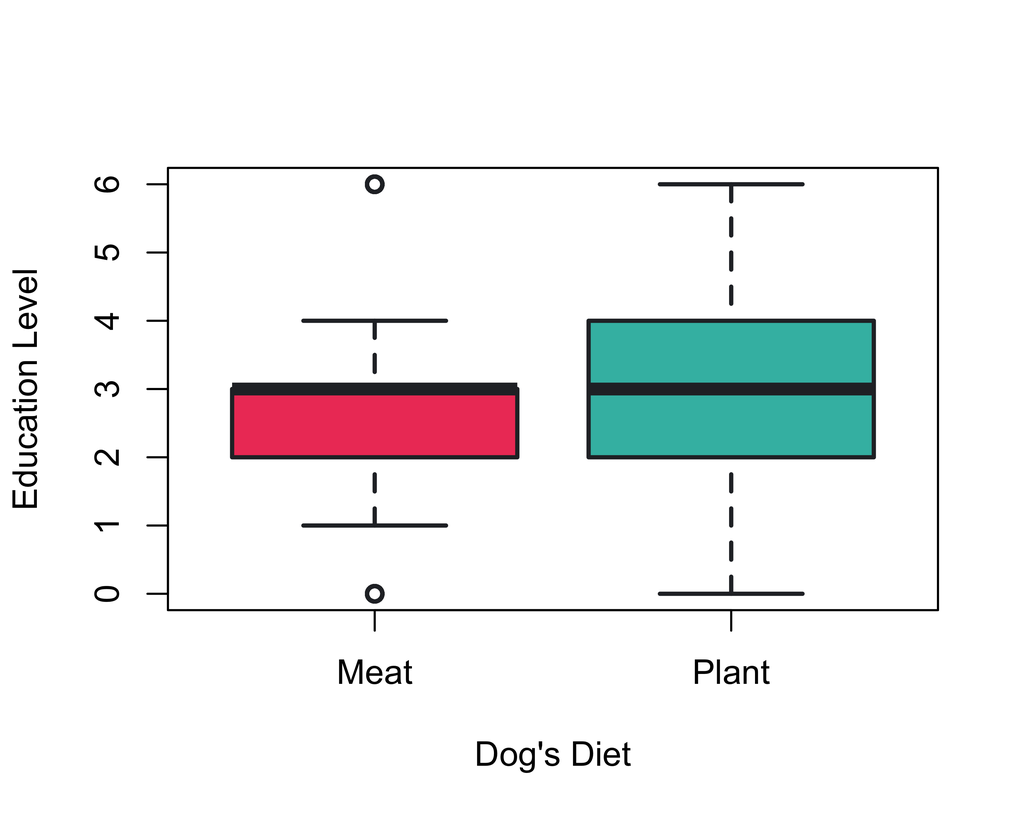

Boxplot showing the education level amongst owners who feed their dogs meat-centric vs. plant-centric diets.

```r
boxplot(education_lvl ~ dog_diet, data = my_data,
        xlab = "Dog's Diet", names.arg = c("Meat-Centric", "Plant-Centric"),         ylab = "Education Level",
        col = c("#EE4266", "#3cbbb1"),
        border = c("#282B30"), lwd = 2)
```

K-nn algorithm:

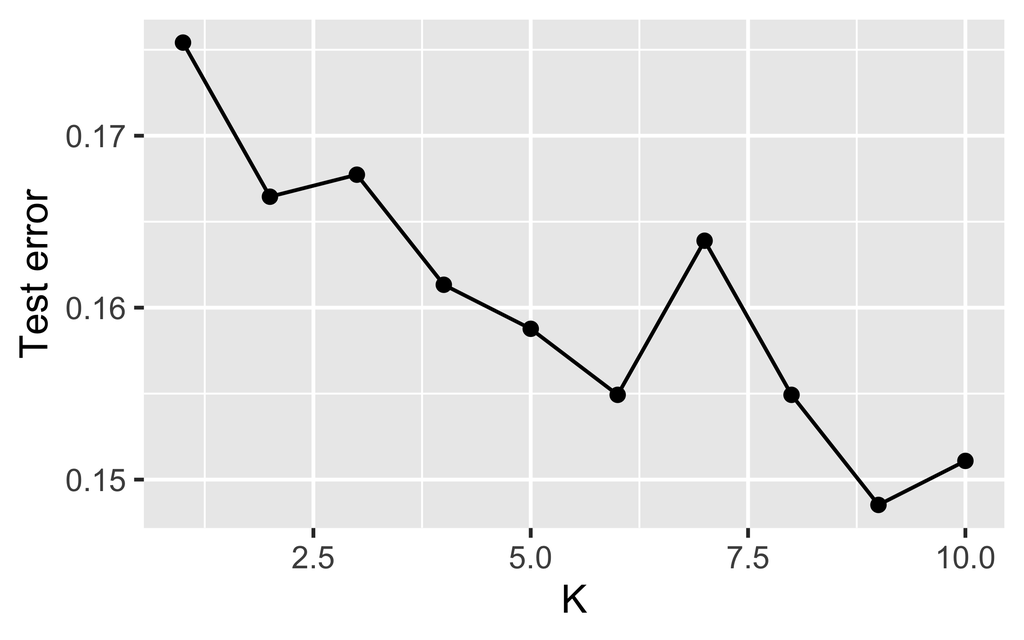

```r
set.seed(1)
full_set = 1:2342
train_sample = sample(full_set, 781, replace = FALSE)
valid_sample = sample(setdiff(full_set, train_sample), 781, replace = FALSE)
test_sample = setdiff(full_set, c(train_sample, valid_sample))

covariates = dplyr::select(my_data, -dog_diet)
response = as.factor(pull(my_data, dog_diet))

data_train = slice(my_data, train_sample)
data_valid = slice(my_data, valid_sample)
data_test = slice(my_data, test_sample)

data_x_train = dplyr::select(data_train, -dog_diet)
data_y_train = dplyr::pull(data_train, dog_diet)
data_x_valid = dplyr::select(data_valid, -dog_diet)
data_y_valid = dplyr::pull(data_valid, dog_diet)
data_x_test = dplyr::select(data_test, -dog_diet)
data_y_test = dplyr::pull(data_test, dog_diet)

K = as.list(c(seq(1,10, by = 1)))

Compute_KNN_test_error = function(k){
  knn_pred_test = knn(data_x_train, data_x_valid,data_y_train, k = k)
  return(1-mean(knn_pred_test == data_y_valid))
}

test_erro_k = lapply(K, Compute_KNN_test_error)

ggplot(
  tibble(K = unlist(K), test_error = unlist(test_erro_k))) +
  geom_point(aes(x = K, y = test_error)) +
  geom_line(aes(x = K, y = test_error)) +
  ylab("Test error")
```

```r
knn_pred_1 = knn(train = data_x_train, test = data_x_test, cl = data_y_train, k = 9)

mean(knn_pred_1 == data_y_test)
```

```
[1] 0.8641026
```

Logistic regression (without shrinkage):

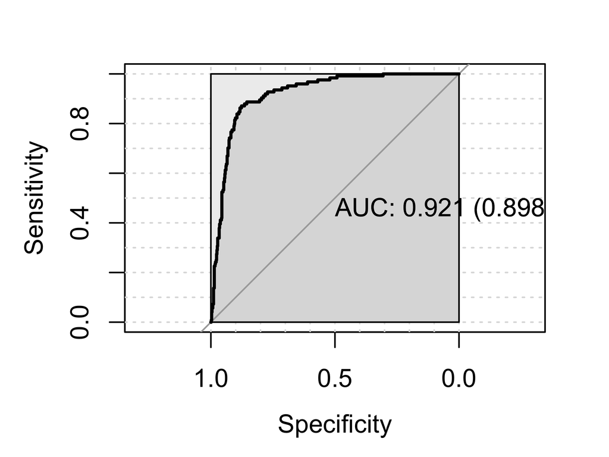

```r
my_data_binary = my_data %>%
  mutate(dog_diet = if_else(dog_diet == "Meat", 1, 0))

glm.fit = glm(dog_diet ~ education_lvl + household_income + owner_age + owner_diet + breed_size + dog_age + neuter_status + vet_visit + dog_meds + dog_health + owner_male + dog_male, data = my_data_binary, family = binomial("logit"), subset = train_sample)

pred_prob = predict(glm.fit, newdata = slice(my_data, valid_sample), type = "response")

pred_df = tibble(pre_prob = pred_prob,
  Y = slice(my_data, valid_sample) %>% pull(dog_diet))

cutoff = 0.5
pred_df = dplyr::mutate(pred_df, dog_diet_predicted = ifelse(pre_prob > cutoff, 1, 0))

tab = table(pred_df$Y, pred_df$dog_diet_predicted)

pred = prediction(pred_df$pre_prob, pred_df$Y)

pROC_graph = roc(pred_df$Y, pred_df$pre_prob, smoothed = TRUE, ci = TRUE, ci.alpha = 0.9, plot = TRUE, auc.polygon = TRUE, max.auc.polygon = TRUE, grid = TRUE, print.auc = TRUE, show.thres = TRUE)
```

```r
coords(pROC_graph, "best")
```

```
  threshold specificity sensitivity
1 0.7307988   0.8767123   0.8709677
```

Using a better cut-off value for the test set:

```r
pred_prob2 = predict(glm.fit, newdata = slice(my_data, test_sample), type = "response")

pred_df2 = tibble(pre_prob = pred_prob2, Y = slice(my_data, test_sample) %>% pull(dog_diet))

cutoff = 0.7307988
pred_df2 = dplyr::mutate(pred_df2, dog_diet_predicted = ifelse(pre_prob > cutoff, 1, 0))

tab2 = table(pred_df2$Y, pred_df2$dog_diet_predicted)

1- sum(diag(tab2))/sum(tab2) # miss-classification error rate
```

```
[1] 0.8705128
```

```r
tab2[2,2]/sum(tab2[2,]) # sensitivity - % correctly predicting as meat diet
```

```
[1] 0.1391304
```

```r
tab2[1,1]/sum(tab2[1,]) # specificity - % correctly predicting as plant diet
```

```
[1] 0.1278195
```

Logistic regression model with shrinkage:

```r
X = model.matrix(dog_diet ~ ., data = my_data_binary)[,-1]

Y = dplyr::pull(my_data_binary, dog_diet)

cv_lasso = cv.glmnet(X[train_sample, ], Y[train_sample], family='binomial', alpha = 1,
  standardize = FALSE)

cv_lasso$lambda.min
```

```
[1] 0.01253655
```

```r
valid_set_pred_log_odds = predict(cv_lasso, newx = X[valid_sample, ], s = "lambda.1se")[,1]

valid_set_pred_prob = exp(valid_set_pred_log_odds)/(1 + exp(valid_set_pred_log_odds))

df_lasso_valid = tibble(
  pre_prob = valid_set_pred_prob,
  y = slice(my_data_binary, valid_sample) %>% pull(dog_diet))

pROC_graph = roc(df_lasso_valid$y, df_lasso_valid$pre_prob, smoothed = TRUE, ci=TRUE, ci.alpha=0.9, stratified=FALSE, plot=FALSE,auc.polygon=TRUE, max.auc.polygon=TRUE, grid=TRUE, print.auc=TRUE, show.thres=TRUE)
```

```r
coords(pROC_graph, "best")
```

```
  threshold specificity sensitivity
1 0.6944256   0.8790323   0.8812785
```

```r
test_set_pred_log_odds = predict(cv_lasso, newx = X[test_sample, ], s = "lambda.1se")[,1]

test_set_pred_prob = exp(test_set_pred_log_odds)/(1 + exp(test_set_pred_log_odds))

df_lasso_test = tibble(pre_prob = test_set_pred_prob,
  y = slice(my_data_binary, test_sample) %>% pull(dog_diet))

cutoff = 0.6944256

dog_diet_test_lasso = dplyr::mutate(
  df_lasso_test,
  dog_diet_predicted = ifelse(
    pre_prob <= cutoff,
    my_data_binary$dog_diet[1],
    my_data_binary$dog_diet[2]
  )
)

tab = table(pull(df_lasso_test, y), pull(dog_diet_test_lasso, dog_diet_predicted))

1- sum(diag(tab))/sum(tab) # miss-classification error rate
```

```
[1] 0.8884615
```

```r
tab[2,2]/sum(tab[2,]) # sensitivity - % correctly predicting as meat diet
```

```
[1] 0.1097744
```

```r
tab[1,1]/sum(tab[1,]) # specificity - % correctly predicting as plant diet
```

```
[1] 0.1217391
```